# Microbial Informatics

## Lecture 24

Patrick D. Schloss, PhD (microbialinformatics.github.io)  
Department of Microbiology & Immunology

## Announcements

- Homework is due on November 22nd
- Will have lab period on Friday
- Final project
  - Due 12/16/2014 (date that final exam is scheduled)
  - Should be a program that others can use to do something useful
  - I have ideas if you need one
  - Create a public repository with documentation in README file and license

## Review

- String manipulation

## Five remaining lectures

- Experiment: Let's write some programs together
- Learning goals:
  - Apply what we've been learning in class
  - Collaborate
- I have no idea how this will work out

## Problem definition

- Vince Young got my wife and I addicted to the iPhone app called [Ruzzle](http://www.ruzzle-game.com)
- It's a 4 by 4 board filled with tiles
- Each tile has a point value associated with it that is proportional to the probability of seeing it in a word (think Scrabble)
- Sometimes there are double letter and double word tiles
- You have two minutes to get as many words as possible
- I'm not very good.

[video not shown]

## Point values

```r
point.values = c(
  'A' = 1,  'B' = 3,  'C' = 3,  'D' = 2,
  'E' = 1,  'F' = 4,  'G' = 2,  'H' = 4,
  'I' = 1,  'J' = 8,  'K' = 5,  'L' = 1,
  'M' = 3,  'N' = 1,  'O' = 1,  'P' = 3,
  'Q' = 10, 'R' = 1,  'S' = 1,  'T' = 1,
  'U' = 1,  'V' = 4,  'W' = 4,  'X' = 8,
  'Y' = 4,  'Z' = 10
)
```

## Example dictionary

- The official Scrabble word list: [SOWPODS](http://www.freescrabbledictionary.com/sowpods.txt)

## Example board: Round 1

[figure not shown]

## Example board: Round 2

[figure not shown]

## Example board: Round 3

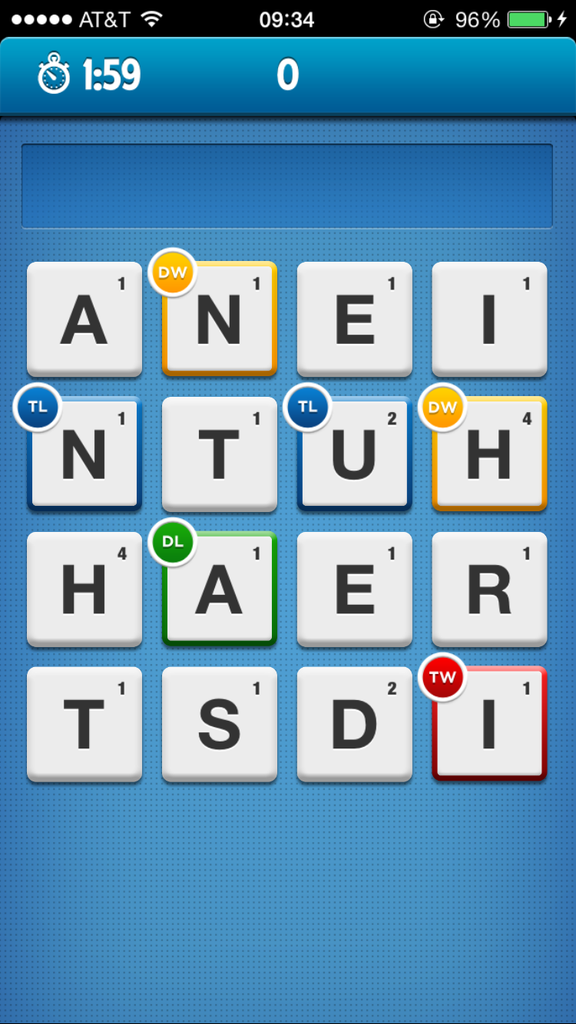

## Organization:

- As a group
  - [GitHub repository](https://github.com/microbialinformatics/ruzzle_cheat)
  - Need to develop broad pseudocode, have class break into groups of 2 or 3
  - Will need to define inputs and outputs so we can work concurrently
- Individually
  - Need to define tests
  - Need to push results to repository at the end of class